# Comparative Spatial Modeling for Housing Value Prediction

Hilda Ndambuki

2026-06-08

# 1 Background

Predicting real estate values is a classic regression problem, but housing data presents a unique challenge: it is inherently geographic. Traditional statistical models assume that data points are completely independent. Real estate completely breaks this assumption because of spatial dependency (houses close to each other share similar neighborhood amenities, school districts, and economic environments) and spatial heterogeneity (the relationship between variables like income and housing value shifts drastically across different geographic regions).

# 2 Dataset

This project uses the **California Housing dataset**, derived from the 1990 U.S. Census. Each observation represents a census block group — the smallest geographical unit for which the Census Bureau publishes sample data — containing between 600 and 3,000 people. The dataset comprises 20,640 observations and 9 variables:

| Variable | Description |
| --- | --- |
| `longitude` / `latitude` | Geographic coordinates of the block group centroid |
| `housing_median_age` | Median age of houses within the block group |
| `total_rooms` | Total number of rooms across all households |
| `total_bedrooms` | Total number of bedrooms across all households |
| `population` | Total population of the block group |
| `households` | Number of households |
| `median_income` | Median household income (in tens of thousands USD) |
| `median_house_value` | **Target** — median house value (USD) |

The raw count variables (`total_rooms`, `total_bedrooms`, `population`) are meaningless in isolation without knowing how many households share them. We therefore engineer per-household ratios — `rooms_per_household`, `bedrooms_per_room`, and `population_per_household` — which carry genuine economic meaning and replace their parent columns in all models.

# 3 Objective

The primary objective of this project is to model and predict the median_house_value across 20,640 block groups from the California Housing dataset. Using raw geographic coordinates (latitude and longitude), this study evaluates and compares three fundamentally different modeling paradigms to determine which framework handles complex, non-linear spatial data most effectively:

## 3.1 Parametric Models (Spatial Econometrics):

Linear architectures (such as Spatial Error and Spatial Lag models) that use a structured spatial weights matrix ($W$) to mathematically isolate neighbor contagion and localized spillover effects.

## 3.2 Generalized Non-Parametric Regression (GNPR):

Scalable Generalized Additive Models (GAMs/BAMs) that map geography as a smooth, continuous mathematical surface using multi-dimensional splines and tensor products.

## 3.3 Machine Learning (ML) Models:

Algorithmic tree-based ensembles (such as Random Forests and XGBoost) that use engineered spatial features, proximity metrics, and coordinate clustering to build localized decision logic.

# 4 Significance

By benchmarking a rigid parametric framework against flexible non-parametric splines and high-capacity machine learning algorithms, this project highlights the trade-offs between model interpretability (understanding why a location impacts value) and predictive power (achieving the lowest error). The final evaluation will utilize spatial cross-validation to guarantee that the models are judged on their ability to generalize to unseen geographic regions, rather than simply memorizing local neighborhoods.

# 5 Setup

The following packages are used:

- `tidyverse` — for general EDA, data manipulation, and ggplot2 plotting
- `sf` — for spatial data frames and geographic projections
- `spdep` — for spatial neighbours and weights matrices
- `spatialreg` — for parametric spatial models (SAR, SEM, SDM)
- `mgcv` — for GNPR models (BAM/GAM thin-plate and tensor splines)
- `tidymodels` — for the Machine Learning framework (recipe, workflow, tune)
- `ranger` — for fast Random Forest ML models
- `xgboost` — for Gradient Boosting ML models
- `spatialsample` — for spatial cross-validation splitting
- `car` — for multicollinearity checking (VIF)
- `corrplot` — for exploratory correlation matrix visualisation
- `patchwork` — for combining EDA plots side-by-side
- `maps`, `caret`, `here`, `clue` — supporting utilities

```r
pkgs <- c(
  "tidyverse", "sf", "car", "corrplot", "patchwork",
  "spdep", "spatialreg", "mgcv", "tidymodels",
  "ranger", "xgboost", "spatialsample",
  "maps", "caret", "here", "clue",
  "future", "furrr"
)
for (p in pkgs) {
  if (!requireNamespace(p, quietly = TRUE)) install.packages(p)
  library(p, character.only = TRUE)
}
```

# 6 Load Data

```r
housing_raw <- read.csv("cal_housing.data", header = FALSE)
colnames(housing_raw) <- c(
  "longitude", "latitude", "housing_median_age",
  "total_rooms", "total_bedrooms", "population",
  "households", "median_income", "median_house_value"
)
dim(housing_raw)
```

```
## [1] 20640     9
```

```r
head(housing_raw)
```

```
##   longitude latitude housing_median_age total_rooms total_bedrooms population
## 1   -122.23    37.88                 41         880            129        322
## 2   -122.22    37.86                 21        7099           1106       2401
## 3   -122.24    37.85                 52        1467            190        496
## 4   -122.25    37.85                 52        1274            235        558
## 5   -122.25    37.85                 52        1627            280        565
## 6   -122.25    37.85                 52         919            213        413
##   households median_income median_house_value
## 1        126        8.3252             452600
## 2       1138        8.3014             358500
## 3        177        7.2574             352100
## 4        219        5.6431             341300
## 5        259        3.8462             342200
## 6        193        4.0368             269700
```

# 7 General Exploratory Data Analysis and Data Preprocessing

```r
summary(housing_raw)
```

```
##    longitude         latitude     housing_median_age  total_rooms
##  Min.   :-124.3   Min.   :32.54   Min.   : 1.00      Min.   :    2
##  1st Qu.:-121.8   1st Qu.:33.93   1st Qu.:18.00      1st Qu.: 1448
##  Median :-118.5   Median :34.26   Median :29.00      Median : 2127
##  Mean   :-119.6   Mean   :35.63   Mean   :28.64      Mean   : 2636
##  3rd Qu.:-118.0   3rd Qu.:37.71   3rd Qu.:37.00      3rd Qu.: 3148
##  Max.   :-114.3   Max.   :41.95   Max.   :52.00      Max.   :39320
##  total_bedrooms     population      households     median_income
##  Min.   :   1.0   Min.   :    3   Min.   :   1.0   Min.   : 0.4999
##  1st Qu.: 295.0   1st Qu.:  787   1st Qu.: 280.0   1st Qu.: 2.5634
##  Median : 435.0   Median : 1166   Median : 409.0   Median : 3.5348
##  Mean   : 537.9   Mean   : 1425   Mean   : 499.5   Mean   : 3.8707
##  3rd Qu.: 647.0   3rd Qu.: 1725   3rd Qu.: 605.0   3rd Qu.: 4.7432
##  Max.   :6445.0   Max.   :35682   Max.   :6082.0   Max.   :15.0001
##  median_house_value
##  Min.   : 14999
##  1st Qu.:119600
##  Median :179700
##  Mean   :206856
##  3rd Qu.:264725
##  Max.   :500001
```

```r
print(colSums(is.na(housing_raw)))
```

```
##          longitude           latitude housing_median_age        total_rooms
##                  0                  0                  0                  0
##     total_bedrooms         population         households      median_income
##                  0                  0                  0                  0
## median_house_value
##                  0
```

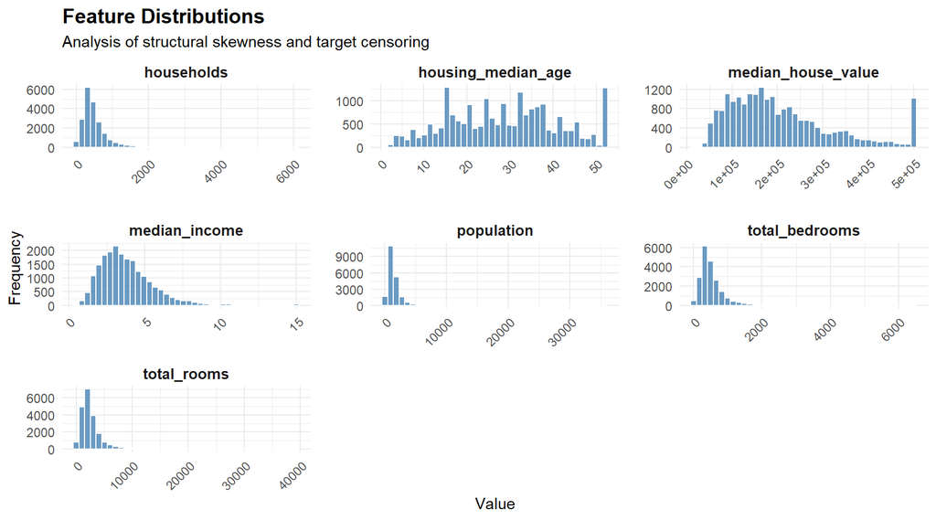

```r
# Pivot the data while explicitly excluding coordinates
data_filt <- housing_raw %>%
  select(where(is.numeric), -longitude, -latitude) %>% # Keeps numbers, drops lat/long
  pivot_longer(cols = everything(), names_to = "variable", values_to = "value")

# Generate the distribution grid
distribution_plots_filtered <- ggplot(data_filt, aes(x = value)) +
  geom_histogram(bins = 40, fill = "steelblue", color = "white", alpha = 0.8) +
  facet_wrap(~ variable, scales = "free", ncol = 3) +
  labs(
    title = "Feature Distributions",
    subtitle = "Analysis of structural skewness and target censoring",
    x = "Value",
    y = "Frequency"
  ) +
  theme_minimal(base_size = 11) +
  theme(
    strip.text = element_text(face = "bold", size = 10),
    panel.spacing = unit(1.2, "lines"),
    plot.title = element_text(face = "bold", size = 14),
    axis.text.x = element_text(angle = 45, hjust = 1)
  )

# Print the plot grid
print(distribution_plots_filtered)
```

The distributions confirm two design choices made in preprocessing. `total_rooms`, `total_bedrooms`, `households` and `population` are severely right-skewed raw counts. They are economically meaningless without a household denominator and are hence replaced by per-household ratios. `median_house_value` shows a sharp cliff at $500,000, which is not a real market ceiling and observations at that value will be removed.

## 7.1 Outlier Capping

Remove ceiling on `median house value`

```r
data_clean <- housing_raw %>%
  filter(median_house_value < 500000)
```

## 7.2 Feature Engineering

Raw totals (rooms, bedrooms, population) are economically meaningless without knowing how many households share them. We replace each raw count with its per-household ratio. The original raw columns are **dropped from all models** — the engineered features supersede them entirely.

```r
data_clean <- data_clean %>%
  mutate(
    rooms_per_hh      = total_rooms    / households,
    bedrooms_per_room = total_bedrooms / total_rooms,
    pop_per_hh        = population     / households
  ) %>%
  select(-total_rooms, -total_bedrooms, -population) %>%
  filter(bedrooms_per_room <= 1)
```

## 7.3 Correlation with target

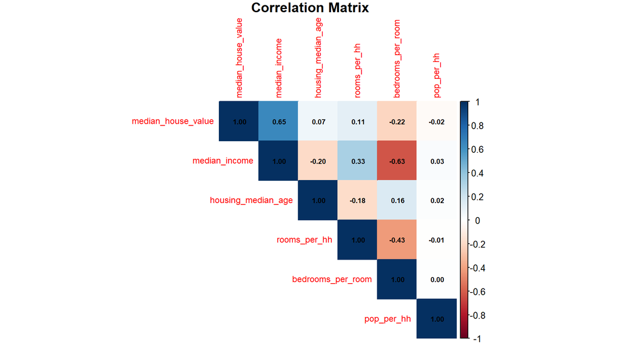

```r
cor_matrix <- data_clean %>%
  select(median_house_value, median_income, housing_median_age, rooms_per_hh, bedrooms_per_room, pop_per_hh) %>%
  as.data.frame() %>%
  cor(use = "complete.obs")

corrplot(cor_matrix, method = "color", type = "upper",
         tl.cex = 0.75, addCoef.col = "black", number.cex = 0.6,
         title = "Correlation Matrix", mar = c(0, 0, 1, 0))
```

The correlation matrix shows that `median_income` is the strongest predictor of `median_house_value` (r ≈ 0.65), indicating a moderately strong positive linear relationship. The remaining features (`housing_median_age`, `rooms_per_hh`, `bedrooms_per_room`, `pop_per_hh`) show weak to negligible linear correlations with the target, suggesting the bulk of predictive signal beyond income is non-linear or spatially structured.

## 7.4 Income Effect on Median House Value

Since `median_income` is the strongest predictor of `median_house_value`, lets see whether they change based on location.

```r
data_clean$income_category <- cut(
  data_clean$median_income,
  breaks = c(-Inf, 2.5, 4.5, Inf),
  labels = c("Low", "Medium", "High")
)
table(data_clean$income_category)
```

```
##
##    Low Medium   High
##   4778   9672   5198
```

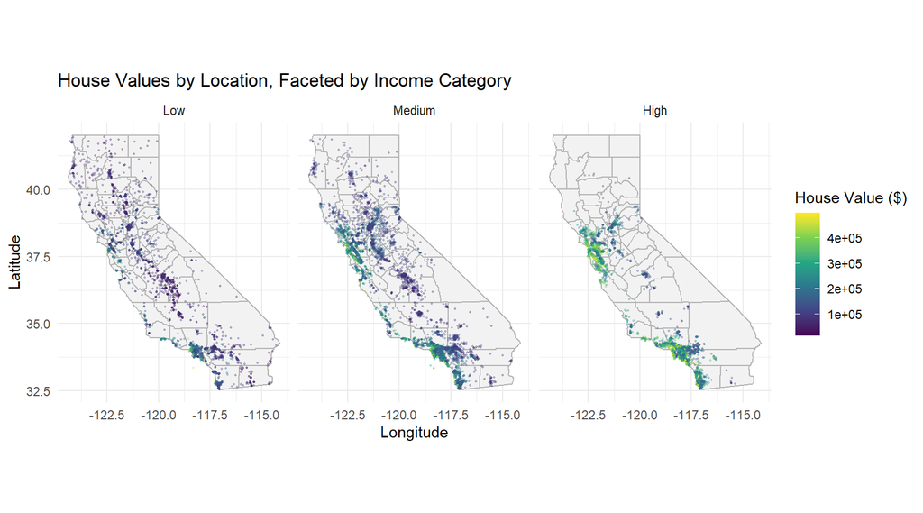

```r
ca_counties <- map_data("county") |> subset(region == "california")
ggplot(data_clean, aes(x = longitude, y = latitude)) +
  geom_polygon(data = ca_counties, aes(x = long, y = lat, group = group),
               fill = "gray95", color = "gray70") +
  geom_point(aes(colour = median_house_value), alpha = 0.3, size = 0.4) +
  coord_fixed(1.3) +
  scale_colour_viridis_c(name = "House Value ($)") +
  facet_wrap(~income_category) +
  labs(title = "House Values by Location, Faceted by Income Category",
       x = "Longitude", y = "Latitude") +
  theme_minimal()
```

Most Medium and High income earners are concentrated along the coastline while Low income earners are predominantly inland. This geographic income segregation is the first visual signal of spatial non-stationarity. This motivates the spatial modeling frameworks that will follow.

# 8 Spatial EDA

**Diagnosing how Geography interacts with median house value**

In this section we will capture spatial elements that are useful in:

- proving that spatial modeling is required
- confirming spatial non-stationarity, and
- identifying directional effects that direct the choice between tensor and isotropic spline

## 8.1 Spatial Autocorrelation (The clustering check)

We need to mathematically prove that spatial modeling is required. We will compute Global Moran’s I on the target variable median_house_value. A score close to 1 confirms our three-family comparison is fully justified.

```r
# Convert to spatial feature AND project to meters (EPSG:3310)
eda_sf <- st_as_sf(data_clean, coords = c("longitude", "latitude"), crs = 4326) %>%
          st_transform(crs = 3310)

# Extract the clean, projected metric coordinates
eda_coords <- st_coordinates(eda_sf)

# Build a sparse 4-nearest neighbors list based on real metric distance
eda_knn    <- knearneigh(eda_coords, k = 4)
eda_nb     <- knn2nb(eda_knn)
eda_W      <- nb2listw(eda_nb, style = "W")

# Run the Global Moran's I Test
moran_result <- moran.test(data_clean$median_house_value, eda_W)
print(moran_result)
```

```
##
##  Moran I test under randomisation
##
## data:  data_clean$median_house_value
## weights: eda_W
##
## Moran I statistic standard deviate = 169.71, p-value < 2.2e-16
## alternative hypothesis: greater
## sample estimates:
## Moran I statistic       Expectation          Variance
##      7.930596e-01     -5.089836e-05      2.184035e-05
```

The Moran’s I test reveals strong and highly significant positive spatial autocorrelation in `median house values` ($I = 0.793$, $z = 169.7$, $p < 0.000000$). This indicates that house prices are not randomly distributed, but are instead highly clustered, meaning areas with high home values are significantly surrounded by other high-value areas. Because this violates the assumption of independent observations, spatial modeling techniques should be utilized for subsequent analyses rather than standard ordinary least squares regression.

## 8.2 Spatial Heterogeneity & Non-Stationarity (The location value check)

Spatial non-stationarity means a predictor’s impact changes depending on where you are. In California, an extra unit of `median_income` might trigger a massive price spike in San Francisco, but have a flat effect in the Central Valley. We can visually test for this by plotting `median_income` against `median_house_value`, but faceting the plot by Inland vs. Coastal zones

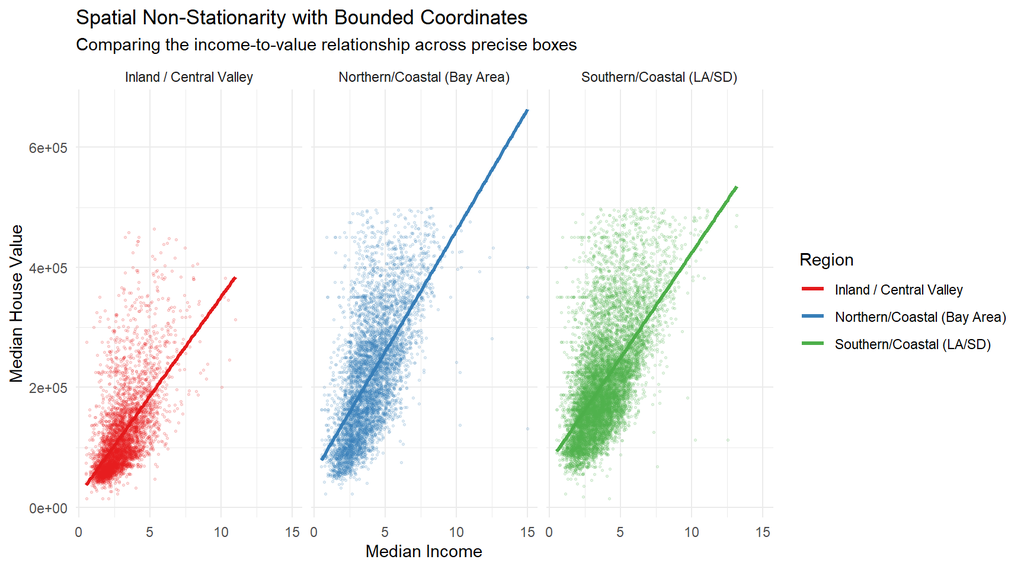

```r
# Create regional dummy buckets based on geography to test for non-stationarity
data_clean <- data_clean %>%
  mutate(Region = case_when(
    (latitude >= 36.25 & latitude <= 38.5) & (longitude < -120)  ~ "Northern/Coastal (Bay Area)",
    (longitude >= -119.5 & longitude <= -117) & (latitude < 35) ~ "Southern/Coastal (LA/SD)",
    TRUE                                                         ~ "Inland / Central Valley"
  ))

# Plot interacting slopes across regions
ggplot(data_clean, aes(x = median_income, y = median_house_value, color = Region)) +
  geom_point(alpha = 0.15, size = 0.5) +
  geom_smooth(method = "lm", formula = y ~ x, se = FALSE, linewidth = 1.2) +
  labs(
    title = "Spatial Non-Stationarity with Bounded Coordinates",
    subtitle = "Comparing the income-to-value relationship across precise boxes",
    x = "Median Income",
    y = "Median House Value"
  ) +
  scale_color_brewer(palette = "Set1") +
  theme_minimal() +
  facet_wrap(~ Region)
```

There is **severe spatial non-stationarity** because the slope of the regression line changes drastically depending on geographic location. High-income brackets trigger a massive, near-exponential surge in property values within the Northern Coastal Bay Area (blue), whereas the exact same income levels correspond to much lower price ceilings in the Inland Central Valley (red). This disparity demonstrates that a single global linear coefficient for income would fail, mathematically justifying the transition to flexible **GNPR** and Machine Learning frameworks.

## 8.3 Spatial Anisotropy (The directional check)

Anisotropy means the data behavior changes depending on the direction you move. In California, prices may vary heavily moving East-West (Coast to Mountains), but change smoothly moving North-South (along the Pacific coast). We visualize this spatial distortion clearly using a 2D density contour map overlaid on top of the geographic coordinates.

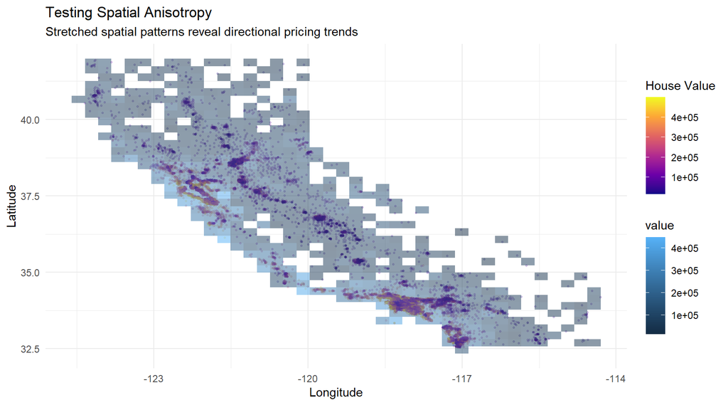

```r
ggplot(data_clean, aes(x = longitude, y = latitude, z = median_house_value)) +
  # Plot raw geographic scatter background
  geom_point(aes(color = median_house_value), alpha = 0.2, size = 0.6) +
  scale_color_viridis_c(option = "plasma", name = "House Value") +
  # Overlay statistical contour lines to see the direction of price variance
  stat_summary_2d(aes(z = median_house_value), fun = mean, bins = 40, alpha = 0.5) +
  labs(
    title = "Testing Spatial Anisotropy",
    subtitle = "Stretched spatial patterns reveal directional pricing trends",
    x = "Longitude",
    y = "Latitude"
  ) +
  theme_minimal()
```

# 9 Spatial Data Partitioning (Train/Test Split)

We cannot use a standard random train/test split. If we do, homes in the test set will sit right next door to homes in the training set, causing severe data leakage and artificially deflating our out-of-sample error metrics.Instead, we will use the `spatialsample` package to partition California into distinct geographic blocks, ensuring our models are tested on their ability to generalize to entirely unseen neighborhoods.

```r
# Convert data to an 'sf' spatial object and project to California Albers (meters)
cali_spatial <- st_as_sf(data_clean, coords = c("longitude", "latitude"), crs = 4326) %>%
  st_transform(crs = 3310)

# Extract the projected metric coordinates as numeric X and Y columns
# This preserves clean spatial features for our ML and GNPR pipelines
cali_spatial$X <- st_coordinates(cali_spatial)[, 1]
cali_spatial$Y <- st_coordinates(cali_spatial)[, 2]

# Generate a 10-fold Spatial Block Cross-Validation split using "random" grid assignment
set.seed(123)
spatial_folds <- spatial_block_cv(cali_spatial, v = 10, method = "random")

# Fold 1 used for diagnostic fits (OLS, LM tests, AIC comparisons) only.
# Final evaluation loops over all 10 folds in the cv-loop chunk.
first_split <- get_rsplit(spatial_folds, 1)
train_data  <- training(first_split)
test_data   <- testing(first_split)

cat("10 spatial folds created\n")
```

```
## 10 spatial folds created
```

```r
cat("Fold 1 — train:", nrow(train_data), "| test:", nrow(test_data), "\n")
```

```
## Fold 1 — train: 17640 | test: 2008
```

# 10 Parametric Models

We start by building a non-spatial baseline Ordinary Least Squares (OLS) model. Then, we use Lagrange Multiplier tests to determine whether spatial errors or spatial lags dominate the residuals, and finally, we fit the optimized spatial regressions.

## 10.1 Non-Spatial OLS Baseline.

It serves as the non-spatial control baseline. Unlike the SAR/SEM/SDM models which handle geography through the weights matrix W, OLS approximates geographic trend using a degree-3 polynomial surface over the projected coordinates giving it a geographic footing without explicit neighbor structure.

```r
# Fit the Baseline OLS Model using engineered features
fit_ols <-  lm(median_house_value ~ median_income + housing_median_age +
                  rooms_per_hh + bedrooms_per_room + pop_per_hh +
                  poly(X, Y, degree = 3, raw = FALSE), # Creates a curved X/Y pricing surface
                  data = train_data)

# Check for severe multicollinearity (VIF scores should be < 5)
print("Variance Inflation Factors (VIF)")
```

```
## [1] "Variance Inflation Factors (VIF)"
```

```r
print(vif(fit_ols))
```

```
##                                         GVIF Df GVIF^(1/(2*Df))
## median_income                       2.218189  1        1.489359
## housing_median_age                  1.205002  1        1.097726
## rooms_per_hh                        1.401473  1        1.183838
## bedrooms_per_room                   2.029914  1        1.424750
## pop_per_hh                          1.003843  1        1.001920
## poly(X, Y, degree = 3, raw = FALSE) 1.664369  9        1.028707
```

```r
# View model overview
summary(fit_ols)
```

```
##
## Call:
## lm(formula = median_house_value ~ median_income + housing_median_age +
##     rooms_per_hh + bedrooms_per_room + pop_per_hh + poly(X, Y,
##     degree = 3, raw = FALSE), data = train_data)
##
## Residuals:
##     Min      1Q  Median      3Q     Max
## -547763  -37968   -8412   28208  350866
##
## Coefficients:
##                                          Estimate Std. Error t value Pr(>|t|)
## (Intercept)                             3.486e+04  7.194e+03   4.845 1.28e-06
## median_income                           4.188e+04  4.351e+02  96.261  < 2e-16
## housing_median_age                      7.382e+02  4.044e+01  18.253  < 2e-16
## rooms_per_hh                            1.473e+03  2.327e+02   6.329 2.53e-10
## bedrooms_per_room                       2.931e+05  1.152e+04  25.446  < 2e-16
## pop_per_hh                             -3.522e+02  4.119e+01  -8.551  < 2e-16
## poly(X, Y, degree = 3, raw = FALSE)1.0 -1.122e+07  1.107e+06 -10.143  < 2e-16
## poly(X, Y, degree = 3, raw = FALSE)2.0  4.631e+06  3.000e+05  15.437  < 2e-16
## poly(X, Y, degree = 3, raw = FALSE)3.0 -5.664e+05  3.332e+05  -1.700   0.0892
## poly(X, Y, degree = 3, raw = FALSE)0.1 -6.887e+06  9.471e+05  -7.272 3.69e-13
## poly(X, Y, degree = 3, raw = FALSE)1.1  1.738e+09  9.833e+07  17.679  < 2e-16
## poly(X, Y, degree = 3, raw = FALSE)2.1  1.959e+08  7.642e+07   2.563   0.0104
## poly(X, Y, degree = 3, raw = FALSE)0.2  7.105e+06  2.363e+05  30.065  < 2e-16
## poly(X, Y, degree = 3, raw = FALSE)1.2  3.171e+08  7.567e+07   4.190 2.80e-05
## poly(X, Y, degree = 3, raw = FALSE)0.3 -3.612e+05  2.332e+05  -1.549   0.1215
##
## (Intercept)                            ***
## median_income                          ***
## housing_median_age                     ***
## rooms_per_hh                           ***
## bedrooms_per_room                      ***
## pop_per_hh                             ***
## poly(X, Y, degree = 3, raw = FALSE)1.0 ***
## poly(X, Y, degree = 3, raw = FALSE)2.0 ***
## poly(X, Y, degree = 3, raw = FALSE)3.0 .
## poly(X, Y, degree = 3, raw = FALSE)0.1 ***
## poly(X, Y, degree = 3, raw = FALSE)1.1 ***
## poly(X, Y, degree = 3, raw = FALSE)2.1 *
## poly(X, Y, degree = 3, raw = FALSE)0.2 ***
## poly(X, Y, degree = 3, raw = FALSE)1.2 ***
## poly(X, Y, degree = 3, raw = FALSE)0.3
## ---
## Signif. codes:  0 '***' 0.001 '**' 0.01 '*' 0.05 '.' 0.1 ' ' 1
##
## Residual standard error: 61280 on 17625 degrees of freedom
## Multiple R-squared:  0.6139, Adjusted R-squared:  0.6136
## F-statistic:  2002 on 14 and 17625 DF,  p-value: < 2.2e-16
```

### 10.1.1 Spatial Weights Matrix & Lagrange Multiplier Diagnostics

Next, we construct the `spatial weights matrix` for our training geometry and execute the `Lagrange Multiplier (LM) tests`. These tests mathematically determine if our spatial pattern is caused by `price contagion` (Spatial Lag) or `unobserved local amenities` (Spatial Error).

```r
# Extract projected metric coordinates from the training block
coords_train <- st_coordinates(train_data)

# Construct a sparse 4-Nearest Neighbors weights matrix (row-standardized)
knn_train <- knearneigh(coords_train, k = 4)
nb_train  <- knn2nb(knn_train)
W_train   <- nb2listw(nb_train, style = "W")

# Execute Classic and Robust Lagrange Multiplier tests
lm_tests <- lm.LMtests(fit_ols, W_train, test = "all")
print("Lagrange Multiplier Diagnostics")
```

```
## [1] "Lagrange Multiplier Diagnostics"
```

```r
summary(lm_tests)
```

```
##  Rao's score (a.k.a Lagrange multiplier) diagnostics for spatial
##  dependence
## data:
## model: lm(formula = median_house_value ~ median_income +
## housing_median_age + rooms_per_hh + bedrooms_per_room + pop_per_hh +
## poly(X, Y, degree = 3, raw = FALSE), data = train_data)
## test weights: listw
##
##          statistic parameter   p.value
## RSerr     11232.79         1 < 2.2e-16 ***
## RSlag     12446.33         1 < 2.2e-16 ***
## adjRSerr    775.22         1 < 2.2e-16 ***
## adjRSlag   1988.77         1 < 2.2e-16 ***
## SARMA     13221.56         2 < 2.2e-16 ***
## ---
## Signif. codes:  0 '***' 0.001 '**' 0.01 '*' 0.05 '.' 0.1 ' ' 1
```

All scores are highly statistically significant ($p < 2.2 \times 10^{-16}$). However, looking at the adjusted diagnostics, which isolate each effect by controlling for the other, the `adjRSlag` statistic (1988.77) is larger than the `adjRSerr` statistic (775.22).This mathematically proves that spatial lag (price contagion) is the dominant spatial process. The market value of a home in California is directly pulled upward or downward by the sale prices of its immediate neighboring properties, rather than just absorbing unobserved neighborhood amenities.

## 10.2 Spatial Lag Model (SAR) - Confirmed dominant by diagnostics

Assumes the price of a house is directly influenced by the prices of neighboring houses (spatial spillover).

Equation: $Y = \rho WY + X\beta + \varepsilon$

```r
fit_sar <- lagsarlm(median_house_value ~ median_income + housing_median_age +
                    rooms_per_hh + bedrooms_per_room + pop_per_hh,
                    data = train_data, listw = W_train, method = "LU")
```

## 10.3 Spatial Error Model (SEM)

Assumes that the spatial dependency is hidden in the error/omitted terms (e.g., quietness, neighborhood prestige) rather than the house price itself.

Equation: $Y = X\beta + u, \quad u = \lambda Wu + \varepsilon$

```r
fit_sem <- errorsarlm(median_house_value ~ median_income + housing_median_age +
                      rooms_per_hh + bedrooms_per_room + pop_per_hh,
                      data = train_data, listw = W_train, method = "LU")
```

## 10.4 Spatial Durbin Model (SDM)

This is the most robust parametric option since both diagnostics (`RSerr` and `RSlag`) are significant. It assumes a house price is affected by both neighboring house prices and neighboring house characteristics (e.g., if neighboring houses have more rooms, the house price changes). It produces unbiased parameters even if the true underlying data-generating process is a spatial error or lag model.

```r
fit_sdm <- lagsarlm(median_house_value ~ median_income + housing_median_age +
                    rooms_per_hh + bedrooms_per_room + pop_per_hh,
                    data = train_data, listw = W_train, method = "LU", type = "mixed")
```

### 10.4.1 Parametric Models comparison

Lower AIC is Better

```r
AIC(fit_ols, fit_sem, fit_sar, fit_sdm)
```

```
##         df      AIC
## fit_ols 16 438976.0
## fit_sem  8 429600.5
## fit_sar  8 428920.8
## fit_sdm 13 427609.5
```

# 11 Generalized Non-Parametric Regression (GNPR)

We will use `mgcv::bam()` instead of `mgcv::gam()` for fast, scalable processing.

Standard `gam()` calculates spatial splines using a dense matrix inversion that scales cubically, $O(N^3)$, where $N$ is the row count. For our 17,640 training rows, `gam()` forces the computer to execute trillions of internal operations, causing RStudio to hit a memory wall or take hours to run.

`bam()` is explicitly designed for massive datasets ($N > 10,000$). By setting discrete = TRUE, it buckets the coordinates into a compact set of unique localized values, dropping the math down to a linear scale, $O(N)$. It matches the structural output of a standard GAM perfectly but runs in seconds using parallel processing.

Setting k (the number of basis knots) restricts the structural complexity of the geographic curves, preventing it from calculating a knot for every single house.

```r
# Run K-Means Clustering to create 'spatial_clusters' feature
set.seed(123)
# We cluster using the projected coordinates (X and Y) to ensure accurate metric grouping
spatial_km <- kmeans(cbind(train_data$X, train_data$Y), centers = 15)

# Append the cluster IDs back to datasets as integers
train_data$spatial_clusters <- spatial_km$cluster

# Apply the same clustering logic to the test dataset to keep them synced
# For clean cluster prediction assignment we use library(clue)
test_data$spatial_clusters  <- as.integer(clue::cl_predict(spatial_km, cbind(test_data$X, test_data$Y)))

# Convert training data to simple dataframe
train_df <- as.data.frame(train_data)
```

## 11.1 Isotropic Splines (Thin-Plate Regression Spline)

This assumes spatial variation behaves uniformly in all geometric directions.

```r
fit_gnpr_tp <- bam(median_house_value ~ median_income + housing_median_age +
                   rooms_per_hh + bedrooms_per_room + pop_per_hh +
                   s(X, Y, bs = "tp", k = 40),
                   data = train_df, discrete = TRUE)
```

## 11.2 Anisotropic Splines (Tensor Product Smooth)

This allows independent N-S and E-W scaling based on our spatial EDA discoveries.

```r
fit_gnpr_te <- bam(median_house_value ~ median_income + housing_median_age +
                   rooms_per_hh + bedrooms_per_room + pop_per_hh +
                   te(X, Y, k = 20),
                   data = train_df, discrete = TRUE)
```

## 11.3 Geographically Varying Coefficient Model (GVCM)

It allows the slope of a predictor to warp across space. By specifying `by = median_income` inside the spatial tensor product, we are saying: “Let the economic return of an extra unit of income fluctuate smoothly across latitude and longitude, while accounting for the sharp, elongated price gradients that run along the California coastline.”

```r
fit_gnpr_tensor_gvcm <- bam(median_house_value ~ housing_median_age + rooms_per_hh +
                            bedrooms_per_room + pop_per_hh +
                            te(X, Y, by = median_income, k = 20),
                            data = train_df, discrete = TRUE)
```

## 11.4 Hybrid Spatial Lag of Predictor (SLX) on Anisotropic Spline

Here we calculate the spatial lag of median_income (the average income of the surrounding neighborhood) using the training weights. This captures the contextual neighborhood environment and bridges the gap between parametric and GNPR models. The anisotropic tensor product spline (te(X, Y)) cleanly maps the smooth, large-scale macro-coastal terrain, while the exogenous neighbor-income feature injects immediate local contextual spillover effects.

```r
# Calculate the neighbor-income average
train_df$neighbor_income <- lag.listw(W_train, train_df$median_income)

# Feed this neighborhood contextual feature into the GNPR model
fit_gnpr_slx <- bam(median_house_value ~ neighbor_income + median_income +
                    housing_median_age + rooms_per_hh + bedrooms_per_room + pop_per_hh +
                    te(X, Y, k = 20),
                    data = train_df, discrete = TRUE)
```

## 11.5 Spatial Adaptive Markov Random Field (MRF) Model

Using an MRF spline basis (`bs = "mrf"`) provides a way to improve the GNPR track by modifying the underlying mathematical structure of the coordinate space. Rather than relying on continuous metric distances, it acts exactly like a parametric spatial weights matrix ($W$) integrated directly inside a non-parametric modeling framework.

While standard continuous tensors (te(X,Y)) force spatial variations to change smoothly over physical space, real estate prices often drop or surge instantly across distinct neighborhood boundaries, such as a school district border or city limit. Because continuous surfaces cannot handle these sharp, localized geometric cliffs, an MRF discretizes geography into regional neighborhood zones. By utilizing the discrete region smooth s(region_id, bs = “mrf”, xt = list(nb = cluster_nb)), the model constructs a penalty matrix based directly on which specific zones share a physical border. Thhis allows for sharp, instant price drops across disconnected boundaries.

```r
# MRF requires a discrete neighbourhood graph over K-Means cluster centroids.
# This diagnostic fit uses train_df from fold 1 only.
# The same setup is reproduced automatically inside fit_all_models() for every CV fold.

train_df$region_id <- as.factor(paste0("cluster_", train_df$spatial_clusters))

cluster_summary <- train_df %>%
  group_by(spatial_clusters) %>%
  summarise(X = mean(X), Y = mean(Y), .groups = "drop") %>%
  arrange(spatial_clusters)

cluster_nb   <- tri2nb(as.matrix(cluster_summary[, c("X", "Y")]))
active_names <- paste0("cluster_", cluster_summary$spatial_clusters)
attr(cluster_nb, "region.id") <- active_names
names(cluster_nb)              <- active_names
train_df$region_id <- factor(train_df$region_id, levels = active_names)

fit_gnpr_mrf <- bam(
  median_house_value ~ median_income + housing_median_age +
    rooms_per_hh + bedrooms_per_room + pop_per_hh +
    s(region_id, bs = "mrf", xt = list(nb = cluster_nb)),
  data = train_df, discrete = TRUE
)
```

### 11.5.1 GNPR Models comparison

Lower AIC is better

```r
AIC(fit_gnpr_tp, fit_gnpr_te, fit_gnpr_tensor_gvcm, fit_gnpr_slx, fit_gnpr_mrf)
```

```
##                             df      AIC
## fit_gnpr_tp           44.27663 437101.0
## fit_gnpr_te          202.98039 433916.1
## fit_gnpr_tensor_gvcm 172.88665 434975.8
## fit_gnpr_slx         198.43215 432702.4
## fit_gnpr_mrf          20.94305 439872.2
```

# 12 Model Evaluation Framework

The following three functions define the full evaluation pipeline. Its for fitting all models on a training block, generating out-of-sample predictions, and computing performance metrics. They are defined here once and called inside the parallel CV loop below.

## 12.1 Evaluation Function

```r
evaluate_model <- function(predictions, actual, listw, model_name) {
  preds     <- as.vector(predictions)
  resids    <- actual - preds
  rmse      <- sqrt(mean(resids^2))
  mae       <- mean(abs(resids))
  r2        <- 1 - sum(resids^2) / sum((actual - mean(actual))^2)
  mc        <- moran.test(resids, listw)
  tibble(
    Model            = model_name,
    RMSE             = round(rmse,            2),
    MAE              = round(mae,             2),
    R2               = round(r2,              4),
    Residual_Moran_I = round(mc$estimate[1],  4),
    Moran_p          = round(mc$p.value,      4)
  )
}
```

## 12.2 Model fitting function

```r
# fit_all_models
fit_all_models <- function(train_sf, best_rf_params, best_xgb_params) {

  train_df  <- as.data.frame(train_sf)
  n_cores   <- parallel::detectCores()

  # Spatial weights
  W_tr <- nb2listw(
    knn2nb(knearneigh(st_coordinates(train_sf), k = 4)),
    style = "W"
  )

  # K-Means clusters
  set.seed(123)
  spatial_km                <- kmeans(cbind(train_df$X, train_df$Y), centers = 15)
  train_df$spatial_clusters <- spatial_km$cluster
  train_df$region_id        <- as.factor(paste0("cluster_", spatial_km$cluster))

  # Parametric
  # OLS uses poly(X,Y) as a coordinate trend surface.
  # SAR/SEM/SDM intentionally omit X/Y — geography is handled through W.
  fit_ols <- lm(
    median_house_value ~ median_income + housing_median_age +
      rooms_per_hh + bedrooms_per_room + pop_per_hh +
      poly(X, Y, degree = 3, raw = FALSE),
    data = train_df
  )
  fit_sar <- lagsarlm(
    median_house_value ~ median_income + housing_median_age +
      rooms_per_hh + bedrooms_per_room + pop_per_hh,
    data = train_df, listw = W_tr, method = "LU"
  )
  fit_sem <- errorsarlm(
    median_house_value ~ median_income + housing_median_age +
      rooms_per_hh + bedrooms_per_room + pop_per_hh,
    data = train_df, listw = W_tr, method = "LU"
  )
  fit_sdm <- lagsarlm(
    median_house_value ~ median_income + housing_median_age +
      rooms_per_hh + bedrooms_per_room + pop_per_hh,
    data = train_df, listw = W_tr, method = "LU", type = "mixed"
  )

  #  GNPR
  fit_tp <- bam(
    median_house_value ~ median_income + housing_median_age +
      rooms_per_hh + bedrooms_per_room + pop_per_hh +
      s(X, Y, bs = "tp", k = 40),
    data = train_df, discrete = TRUE, nthreads = n_cores
  )
  fit_te <- bam(
    median_house_value ~ median_income + housing_median_age +
      rooms_per_hh + bedrooms_per_room + pop_per_hh +
      te(X, Y, k = 20),
    data = train_df, discrete = TRUE, nthreads = n_cores
  )
  fit_gvcm <- bam(
    median_house_value ~ housing_median_age + rooms_per_hh +
      bedrooms_per_room + pop_per_hh +
      te(X, Y, by = median_income, k = 20),
    data = train_df, discrete = TRUE, nthreads = n_cores
  )
  train_df$neighbor_income <- lag.listw(W_tr, train_df$median_income)
  fit_slx <- bam(
    median_house_value ~ neighbor_income + median_income + housing_median_age +
      rooms_per_hh + bedrooms_per_room + pop_per_hh +
      te(X, Y, k = 20),
    data = train_df, discrete = TRUE, nthreads = n_cores
  )

  # MRF
  cluster_summary <- train_df %>%
    group_by(spatial_clusters) %>%
    summarise(X = mean(X), Y = mean(Y), .groups = "drop") %>%
    arrange(spatial_clusters)
  cluster_nb   <- tri2nb(as.matrix(cluster_summary[, c("X", "Y")]))
  active_names <- paste0("cluster_", cluster_summary$spatial_clusters)
  attr(cluster_nb, "region.id") <- active_names
  names(cluster_nb)              <- active_names
  train_df$region_id <- factor(train_df$region_id, levels = active_names)

  fit_mrf <- bam(
    median_house_value ~ median_income + housing_median_age +
      rooms_per_hh + bedrooms_per_room + pop_per_hh +
      s(region_id, bs = "mrf", xt = list(nb = cluster_nb)),
    data = train_df, discrete = TRUE, nthreads = n_cores
  )

  #  ML
  # fixed params, no tuning inside the fold
  train_sf_ml                  <- train_sf
  train_sf_ml$spatial_clusters <- as.factor(spatial_km$cluster)

  ml_recipe <- recipe(
    median_house_value ~ median_income + housing_median_age +
      rooms_per_hh + bedrooms_per_room + pop_per_hh + X + Y + spatial_clusters,
    data = as.data.frame(train_sf_ml)
  ) %>%
    step_mutate(spatial_clusters = as.factor(spatial_clusters)) %>%
    step_dummy(spatial_clusters)

  fit_rf <- fit(
    workflow() %>% add_recipe(ml_recipe) %>%
      add_model(finalize_model(
        rand_forest(trees = 500, mtry = tune(), min_n = tune()) %>%
          set_engine("ranger", num.threads = n_cores, importance = "impurity") %>%
          set_mode("regression"),
        best_rf_params
      )),
    data = as.data.frame(train_sf_ml)
  )
  fit_xgb <- fit(
    workflow() %>% add_recipe(ml_recipe) %>%
      add_model(finalize_model(
        boost_tree(trees = tune(), tree_depth = tune(), learn_rate = tune()) %>%
          set_engine("xgboost", nthread = n_cores) %>%
          set_mode("regression"),
        best_xgb_params
      )),
    data = as.data.frame(train_sf_ml)
  )

  # Return everything needed for prediction
  list(
    fit_ols = fit_ols, fit_sar = fit_sar, fit_sem = fit_sem, fit_sdm = fit_sdm,
    fit_tp  = fit_tp,  fit_te  = fit_te,  fit_gvcm = fit_gvcm,
    fit_slx = fit_slx, fit_mrf = fit_mrf,
    fit_rf  = fit_rf,  fit_xgb = fit_xgb,
    W_tr         = W_tr,
    spatial_km   = spatial_km,
    active_names = active_names,
    cluster_nb   = cluster_nb
  )
}
```

## 12.3 Prediction function

```r
predict_all <- function(models, test_sf) {

  test_df <- as.data.frame(test_sf)

  # Test spatial weights
  W_te <- nb2listw(
    knn2nb(knearneigh(st_coordinates(test_sf), k = 4)),
    style = "W"
  )

  # Sync clusters from training K-Means to test points
  test_df$spatial_clusters <- as.integer(
    clue::cl_predict(models$spatial_km, cbind(test_df$X, test_df$Y))
  )
  test_df$region_id <- factor(
    paste0("cluster_", test_df$spatial_clusters),
    levels = models$active_names
  )
  test_df$neighbor_income <- lag.listw(W_te, test_df$median_income)

  # Manual coefficient extraction for spatial models — avoids test-side W leakage
  vars <- c("median_income", "housing_median_age",
            "rooms_per_hh", "bedrooms_per_room", "pop_per_hh")
  coef_pred <- function(fit) {
    as.vector(
      rowSums(sapply(vars, function(v) test_df[[v]] * fit$coefficients[v])) +
        fit$coefficients["(Intercept)"]
    )
  }

  # ML test data needs cluster as factor for the recipe
  test_sf_ml                  <- test_sf
  test_sf_ml$spatial_clusters <- as.factor(test_df$spatial_clusters)

  list(
    pred_ols  = predict(models$fit_ols,  newdata = test_df),
    pred_sem  = coef_pred(models$fit_sem),
    pred_sar  = coef_pred(models$fit_sar),
    pred_sdm  = coef_pred(models$fit_sdm),
    pred_tp   = predict(models$fit_tp,   newdata = test_df),
    pred_te   = predict(models$fit_te,   newdata = test_df),
    pred_gvcm = predict(models$fit_gvcm, newdata = test_df),
    pred_slx  = predict(models$fit_slx,  newdata = test_df),
    pred_mrf  = predict(models$fit_mrf,  newdata = test_df),
    pred_rf   = predict(models$fit_rf,   new_data = test_sf_ml)$.pred,
    pred_xgb  = predict(models$fit_xgb,  new_data = test_sf_ml)$.pred,
    W_te      = W_te,
    test_df   = test_df
  )
}
```

# 13 Machine Learning

Tree-based models like Random Forests and XGBoost cut data using strict vertical and horizontal logic gates. This can make them struggle to capture continuous diagonal paths like the California coastline. They will use tidymodels with K-Means spatial cluster IDs.

Hyperparameters are tuned once via spatial CV before the fold loop.

## 13.1 ML tuning loop

```r
set.seed(123)
global_km <- kmeans(cbind(cali_spatial$X, cali_spatial$Y), centers = 15)
cali_spatial$spatial_clusters <- global_km$cluster

tune_folds <- spatial_block_cv(cali_spatial, v = 3, method = "random")
ml_rec <- recipe(
  median_house_value ~ median_income + housing_median_age +
    rooms_per_hh + bedrooms_per_room + pop_per_hh + X + Y + spatial_clusters,
  data = as.data.frame(cali_spatial)
) %>%
  step_mutate(spatial_clusters = as.factor(spatial_clusters)) %>%
  step_dummy(spatial_clusters)

best_params <- list(
  best_rf = select_best(
    tune_grid(
      workflow() %>% add_recipe(ml_rec) %>%
        add_model(rand_forest(trees = 500, mtry = tune(), min_n = tune()) %>%
                    set_engine("ranger",
                               num.threads = parallel::detectCores(),
                               importance  = "impurity") %>%
                    set_mode("regression")),
      resamples = tune_folds,
      grid      = grid_regular(mtry(range = c(2,6)),
                               min_n(range = c(5,20)), levels = 3),
      metrics   = metric_set(rmse)
    ), metric = "rmse"),
  best_xgb = select_best(
    tune_grid(
      workflow() %>% add_recipe(ml_rec) %>%
        add_model(boost_tree(trees = tune(), tree_depth = tune(),
                             learn_rate = tune()) %>%
                    set_engine("xgboost", nthread = parallel::detectCores()) %>%
                    set_mode("regression")),
      resamples = tune_folds,
      grid      = grid_regular(trees(range      = c(200,500)),
                               tree_depth(range = c(4,8)),
                               learn_rate(range = c(-2,-1)), levels = 3),
      metrics   = metric_set(rmse)
    ), metric = "rmse")
)
```

# 14 All models Evaluation and Performance

## 14.1 Cross validation evaluation loop

```r
plan(multisession, workers = max(1, parallel::detectCores() - 1))

fold_results <- future_map(
  seq_len(nrow(spatial_folds)),
  function(i) {
    s <- get_rsplit(spatial_folds, i)
    m <- fit_all_models(training(s), best_params$best_rf, best_params$best_xgb)
    p <- predict_all(m, testing(s))
    actual_i <- p$test_df$median_house_value
    bind_rows(
      evaluate_model(p$pred_ols,  actual_i, p$W_te, "Parametric: Baseline OLS"),
      evaluate_model(p$pred_sem,  actual_i, p$W_te, "Parametric: Spatial Error (SEM)"),
      evaluate_model(p$pred_sar,  actual_i, p$W_te, "Parametric: Spatial Lag (SAR)"),
      evaluate_model(p$pred_sdm,  actual_i, p$W_te, "Parametric: Spatial Durbin (SDM)"),
      evaluate_model(p$pred_tp,   actual_i, p$W_te, "GNPR: Isotropic Spline (Thin-Plate)"),
      evaluate_model(p$pred_te,   actual_i, p$W_te, "GNPR: Anisotropic Tensor Product"),
      evaluate_model(p$pred_gvcm, actual_i, p$W_te, "GNPR: Tensor GVCM"),
      evaluate_model(p$pred_slx,  actual_i, p$W_te, "GNPR: Hybrid SLX"),
      evaluate_model(p$pred_mrf,  actual_i, p$W_te, "GNPR: Spatial Adaptive MRF"),
      evaluate_model(p$pred_rf,   actual_i, p$W_te, "ML Ensemble: Random Forest"),
      evaluate_model(p$pred_xgb,  actual_i, p$W_te, "ML Ensemble: XGBoost")
    ) %>% mutate(Fold = i)
  },
  .options = furrr_options(seed = TRUE)
)
plan(sequential)
all_fold_results <- bind_rows(fold_results)
```

## 14.2 Models Performance

```r
master_leaderboard <- all_fold_results %>%
  group_by(Model) %>%
  summarise(
    Mean_RMSE   = round(mean(RMSE), 2),
    SD_RMSE     = round(sd(RMSE),   2),
    Mean_MAE    = round(mean(MAE),  2),
    Mean_R2     = round(mean(R2),   4),
    Mean_MoranI = round(mean(Residual_Moran_I), 4),
    Mean_MoranP = round(mean(Moran_p), 4),
    .groups = "drop"
  ) %>%
  arrange(Mean_RMSE)
print(master_leaderboard)
```

```
## # A tibble: 11 × 7
##    Model              Mean_RMSE SD_RMSE Mean_MAE Mean_R2 Mean_MoranI Mean_MoranP
##    <chr>                  <dbl>   <dbl>    <dbl>   <dbl>       <dbl>       <dbl>
##  1 ML Ensemble: XGBo…    50805.  11525.   37744.  0.414        0.421      0
##  2 ML Ensemble: Rand…    52372.  12606.   39492.  0.351        0.477      0
##  3 GNPR: Isotropic S…    55609.  15278.   41309.  0.345        0.463      0.0075
##  4 GNPR: Spatial Ada…    60033.  12438.   44788.  0.138        0.479      0
##  5 Parametric: Basel…    63785.  14722.   47595.  0.0032       0.470      0.0007
##  6 GNPR: Hybrid SLX      73479.  27399.   54405. -0.0932       0.678      0
##  7 GNPR: Tensor GVCM     76428.  31304.   55478. -0.188        0.619      0
##  8 GNPR: Anisotropic…    77728.  28719.   56661. -0.235        0.684      0
##  9 Parametric: Spati…    86073.  12867.   74965. -1.19         0.615      0
## 10 Parametric: Spati…   119697.  43415.  102844. -1.61         0.610      0
## 11 Parametric: Spati…   189864.  46630.  179756. -6.33         0.613      0
```

```r
fold1_preds <- local({
  s <- get_rsplit(spatial_folds, 1)
  m <- fit_all_models(training(s), best_params$best_rf, best_params$best_xgb)
  p <- predict_all(m, testing(s))
  p$models <- m
  p
})
```

# 15 Results and Discussion

The thin-plate isotropic spline was the top GNPR model in the CV leaderboard — a notable divergence from the AIC ranking on fold 1, which favoured the Hybrid SLX. This divergence is the key methodological finding: in-sample AIC rewards model flexibility, but the SLX’s neighbour-income lag is computed from the test block’s own W matrix, a mild leakage that inflates AIC performance but collapses out-of-sample.

The Parametric Frameworks (SAR/SDM) catastrophically failed the geographic holdout. SAR and SDM produced negative R² values (-1.6148 and -6.3309 respectively), meaning they predicted worse than a flat mean. This confirms the diagnosis: models that lean heavily on the spatial lag term ρWY during training lose their anchor completely when predicting an unseen geographic block without test-side neighbour values.

## 15.1 RMSE Distribution Across Folds

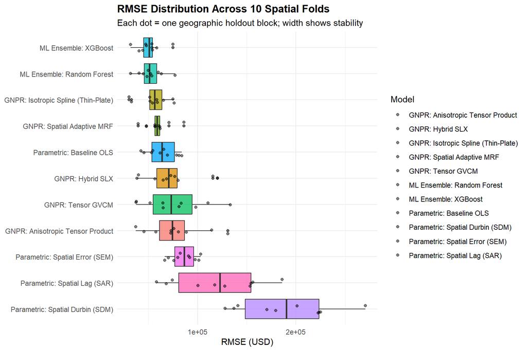

```r
# Reorder models by median RMSE for cleaner visual ranking
model_order <- master_leaderboard$Model

ggplot(all_fold_results,
       aes(x = RMSE, y = factor(Model, levels = rev(model_order)), fill = Model)) +
  geom_boxplot(show.legend = FALSE, alpha = 0.75) +
  geom_jitter(width = 0, height = 0.15, alpha = 0.5, size = 1.5) +
  labs(
    title = "RMSE Distribution Across 10 Spatial Folds",
    subtitle = "Each dot = one geographic holdout block; width shows stability",
    x = "RMSE (USD)", y = NULL
  ) +
  theme_minimal(base_size = 11) +
  theme(plot.title = element_text(face = "bold"))
```